## 1. Binary Classification: Predicting Marijuana Use (MRJFLAG)

## 2. Multi-Class Classification: Predicting Alcohol Frequency (AlcoholFreq)

## 3. Regression: Predicting Cigarette Days (CigaretteUsageDays)

```r
library(rpart)
library(randomForest)
library(dplyr)
library(gbm)
library(caret)
library(pROC)
library(pdp)
```

```r
library(rpart.plot)     # Using it for plotting decision trees
library(tree)
rm(list = ls())
load("youth_data.Rdata")
ls()
```

```
## [1] "demographic_cols"      "df"                    "substance_cols"
## [4] "youth_experience_cols"
```

```r
head(df, 5)
```

```
##   IRALCFY IRMJFY IRCIGFM IRSMKLSS30N IRALCFM IRMJFM IRCIGAGE IRSMKLSSTRY
## 1     991    991      91          91      91     91      991         991
## 2     991     60      91          91      91      2      991         991
## 3       1    991      91          91      93     91      991         991
## 4     991    991      91          91      91     91      991         991
## 5     991    991      91          91      91     91      991         991
##   IRALCAGE IRMJAGE MRJFLAG ALCFLAG TOBFLAG ALCYDAYS MRJYDAYS ALCMDAYS MRJMDAYS
## 1      991     991       0       0       0        6        6        5        5
## 2      991      14       1       0       0        6        3        5        1
## 3       11     991       0       1       0        1        6        5        5
## 4      991     991       0       0       0        6        6        5        5
## 5      991     991       0       0       0        6        6        5        5
##   CIGMDAYS SMKLSMDAYS SCHFELT TCHGJOB AVGGRADE STNDSCIG STNDSMJ STNDALC STNDDNK
## 1        6          5       1       1        2        2       2       2       2
## 2        6          5       2       1        2        1       1       1       1
```

[output cut: 45 more lines]

```r
colnames(df)
```

```
##  [1] "IRALCFY"     "IRMJFY"      "IRCIGFM"     "IRSMKLSS30N" "IRALCFM"
##  [6] "IRMJFM"      "IRCIGAGE"    "IRSMKLSSTRY" "IRALCAGE"    "IRMJAGE"
## [11] "MRJFLAG"     "ALCFLAG"     "TOBFLAG"     "ALCYDAYS"    "MRJYDAYS"
## [16] "ALCMDAYS"    "MRJMDAYS"    "CIGMDAYS"    "SMKLSMDAYS"  "SCHFELT"
## [21] "TCHGJOB"     "AVGGRADE"    "STNDSCIG"    "STNDSMJ"     "STNDALC"
## [26] "STNDDNK"     "PARCHKHW"    "PARHLPHW"    "PRCHORE2"    "PRLMTTV2"
## [31] "PARLMTSN"    "PRGDJOB2"    "PRPROUD2"    "ARGUPAR"     "YOFIGHT2"
## [36] "YOGRPFT2"    "YOHGUN2"     "YOSELL2"     "YOSTOLE2"    "YOATTAK2"
## [41] "PRPKCIG2"    "PRMJEVR2"    "PRMJMO"      "PRALDLY2"    "YFLPKCG2"
## [46] "YFLTMRJ2"    "YFLMJMO"     "YFLADLY2"    "FRDPCIG2"    "FRDMEVR2"
## [51] "FRDMJMON"    "FRDADLY2"    "TALKPROB"    "PRTALK3"     "PRBSOLV2"
## [56] "PREVIOL2"    "PRVDRGO2"    "GRPCNSL2"    "PREGPGM2"    "YTHACT2"
## [61] "DRPRVME3"    "ANYEDUC3"    "RLGATTD"     "RLGIMPT"     "RLGDCSN"
## [66] "RLGFRND"     "IRSEX"       "NEWRACE2"    "HEALTH2"     "EDUSCHLGO"
## [71] "EDUSCHGRD2"  "EDUSKPCOM"   "IMOTHER"     "IFATHER"     "INCOME"
## [76] "GOVTPROG"    "POVERTY3"    "PDEN10"      "COUTYP4"
```

## 1. Binary Classification: Predicting Marijuana Use (MRJFLAG)

# Data Prep

```r
target_binary <- "MarijuanaUse"
df <- df %>% rename(MarijuanaUse = MRJFLAG)
```

```r
predictors_binary <- c(
  "ParentalDisapproval",
  "SchoolPunishment",
  "GroupFights",
  "Friends_Use_MJ",
  "FriendsOfferedMJ",
  "ParentsUseMJ"
)
```

```r
df <- df %>% rename(
  FriendsUseMJ = FRDMEVR2,
  FriendsOfferedMJ = YFLTMRJ2,
  ParentsUseMJ = PRMJEVR2,
  ParentalDisapproval = PRMJMO,
  SchoolPunishment = STNDSMJ,
  GroupFights = YOGRPFT2
)
```

```r
# 1 = Used & 0 = Not Used
df$MarijuanaUse <- ifelse(df$MarijuanaUse == 1, 1, 0)
```

```r
predictors_binary <- c("FriendsUseMJ", "FriendsOfferedMJ", "ParentsUseMJ", "ParentalDisapproval", "SchoolPunishment", "GroupFights")
target_binary <- "MarijuanaUse"
```

```r
clean_df <- na.omit(df[, c(target_binary, predictors_binary)])


clean_df[[target_binary]] <- as.factor(clean_df[[target_binary]])
```

Above, I am converting target to factor, removes rows with NA’s in the columns used for modeling.

```r
set.seed(1)
train <- createDataPartition(clean_df[[target_binary]], p = 0.7, list = FALSE)
data.train <- clean_df[train, ]
data.test <- clean_df[-train, ]
```

Used createDataPartition to split the data into training and testing sets. It was the best way which was ensuring that the target variable is balanced in both sets. Reference: https://www.rdocumentation.org/packages/caret/versions/6.0-94/topics/createDataPartition

# Decision Tree (With and Without Pruning)

```r
# Fitting unpruned tree
tree_unpruned <- rpart(
  paste(target_binary, "~", paste(predictors_binary, collapse = "+")),
  data = data.train,
  method = "class",
  control = rpart.control(cp = 0, minsplit = 10)
)
```

```r
summary(tree_unpruned)
```

```
## Call:
## rpart(formula = paste(target_binary, "~", paste(predictors_binary,
##     collapse = "+")), data = data.train, method = "class", control = rpart.control(cp = 0,
##     minsplit = 10))
##   n= 6975
##
##             CP nsplit rel error    xerror       xstd
## 1 0.0746543779      0 1.0000000 1.0000000 0.02789785
## 2 0.0423963134      2 0.8506912 0.8534562 0.02611833
## 3 0.0082949309      3 0.8082949 0.8110599 0.02555797
## 4 0.0024577573      4 0.8000000 0.8119816 0.02557039
## 5 0.0013824885      7 0.7926267 0.8046083 0.02547073
## 6 0.0006144393      9 0.7898618 0.7981567 0.02538295
## 7 0.0004608295     12 0.7880184 0.7981567 0.02538295
## 8 0.0000000000     14 0.7870968 0.7990783 0.02539553
##
## Variable importance
##        FriendsUseMJ    SchoolPunishment    FriendsOfferedMJ ParentalDisapproval
##                  38                  20                  19                  11
##        ParentsUseMJ         GroupFights
##                  11                   1
##
## Node number 1: 6975 observations,    complexity param=0.07465438
##   predicted class=0  expected loss=0.1555556  P(node) =1
##     class counts:  5890  1085
##    probabilities: 0.844 0.156
##   left son=2 (5398 obs) right son=3 (1577 obs)
##   Primary splits:
##       FriendsUseMJ        splits as  LR, improve=312.5028, (0 missing)
##       SchoolPunishment    splits as  RL, improve=309.8958, (0 missing)
##       FriendsOfferedMJ    splits as  LR, improve=288.3049, (0 missing)
##       ParentalDisapproval splits as  LR, improve=236.2693, (0 missing)
##       ParentsUseMJ        splits as  LR, improve=231.4970, (0 missing)
##   Surrogate splits:
##       FriendsOfferedMJ    splits as  LR, agree=0.867, adj=0.410, (0 split)
##       ParentsUseMJ        splits as  LR, agree=0.821, adj=0.210, (0 split)
##       ParentalDisapproval splits as  LR, agree=0.819, adj=0.201, (0 split)
##
## Node number 2: 5398 observations,    complexity param=0.002457757
##   predicted class=0  expected loss=0.07465728  P(node) =0.7739068
```

[output cut: 192 more lines]

```
##
## Node number 93: 41 observations
##   predicted class=1  expected loss=0.4634146  P(node) =0.005878136
##     class counts:    19    22
##    probabilities: 0.463 0.537
##
## Node number 124: 4 observations
##   predicted class=0  expected loss=0.25  P(node) =0.0005734767
##     class counts:     3     1
##    probabilities: 0.750 0.250
##
## Node number 125: 8 observations
##   predicted class=1  expected loss=0.375  P(node) =0.001146953
##     class counts:     3     5
##    probabilities: 0.375 0.625
```

Made use of rpart library as it was easy to implement and I was facing continued issues with basic r code and cv.tree code. rpart.control -> sets complexity parameter (cp) to 0 - means no pruning. minsplit -> 10, means a node must have at least 10 observations to be split. Reference: https://www.rdocumentation.org/packages/rpart/versions/4.1.24/topics/rpart

```r
# Pruning tree
pruned_tree <- prune(tree_unpruned, cp = 0.01)
```

```r
summary(pruned_tree)
```

```
## Call:
## rpart(formula = paste(target_binary, "~", paste(predictors_binary,
##     collapse = "+")), data = data.train, method = "class", control = rpart.control(cp = 0,
##     minsplit = 10))
##   n= 6975
##
##           CP nsplit rel error    xerror       xstd
## 1 0.07465438      0 1.0000000 1.0000000 0.02789785
## 2 0.04239631      2 0.8506912 0.8534562 0.02611833
## 3 0.01000000      3 0.8082949 0.8110599 0.02555797
##
## Variable importance
##        FriendsUseMJ    FriendsOfferedMJ    SchoolPunishment        ParentsUseMJ
##                  45                  22                  14                   9
## ParentalDisapproval
##                   9
##
## Node number 1: 6975 observations,    complexity param=0.07465438
##   predicted class=0  expected loss=0.1555556  P(node) =1
##     class counts:  5890  1085
##    probabilities: 0.844 0.156
##   left son=2 (5398 obs) right son=3 (1577 obs)
##   Primary splits:
##       FriendsUseMJ        splits as  LR, improve=312.5028, (0 missing)
##       SchoolPunishment    splits as  RL, improve=309.8958, (0 missing)
##       FriendsOfferedMJ    splits as  LR, improve=288.3049, (0 missing)
##       ParentalDisapproval splits as  LR, improve=236.2693, (0 missing)
##       ParentsUseMJ        splits as  LR, improve=231.4970, (0 missing)
##   Surrogate splits:
##       FriendsOfferedMJ    splits as  LR, agree=0.867, adj=0.410, (0 split)
##       ParentsUseMJ        splits as  LR, agree=0.821, adj=0.210, (0 split)
##       ParentalDisapproval splits as  LR, agree=0.819, adj=0.201, (0 split)
##
## Node number 2: 5398 observations
##   predicted class=0  expected loss=0.07465728  P(node) =0.7739068
##     class counts:  4995   403
##    probabilities: 0.925 0.075
##
## Node number 3: 1577 observations,    complexity param=0.07465438
##   predicted class=0  expected loss=0.4324667  P(node) =0.2260932
```

[output cut: 22 more lines]

```
##   Primary splits:
##       FriendsOfferedMJ    splits as  LR, improve=23.322840, (0 missing)
##       ParentalDisapproval splits as  LR, improve=21.443260, (0 missing)
##       ParentsUseMJ        splits as  LR, improve=19.684800, (0 missing)
##       GroupFights         splits as  RL, improve= 2.619845, (0 missing)
##
## Node number 14: 228 observations
##   predicted class=0  expected loss=0.3991228  P(node) =0.03268817
##     class counts:   137    91
##    probabilities: 0.601 0.399
##
## Node number 15: 640 observations
##   predicted class=1  expected loss=0.3375  P(node) =0.09175627
##     class counts:   216   424
##    probabilities: 0.338 0.662
```

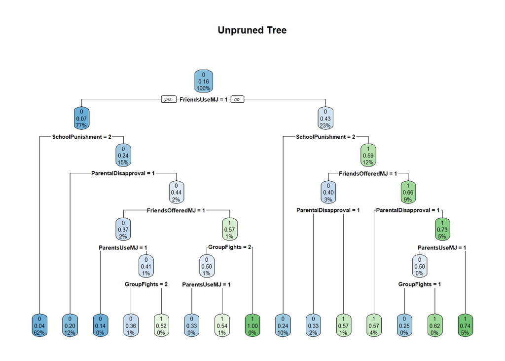

```r
rpart.plot(tree_unpruned, main = "Unpruned Tree")
```

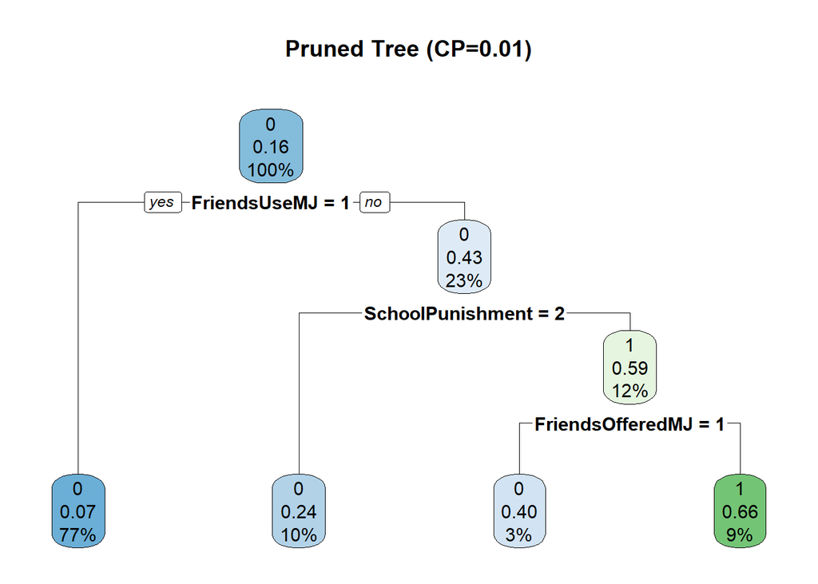

```r
rpart.plot(pruned_tree, main = "Pruned Tree (CP=0.01)")
```

Using rpart.plot for better visualization of decision trees. Reference: https://www.rdocumentation.org/packages/rpart.plot/versions/3.1.2/topics/rpart.plot

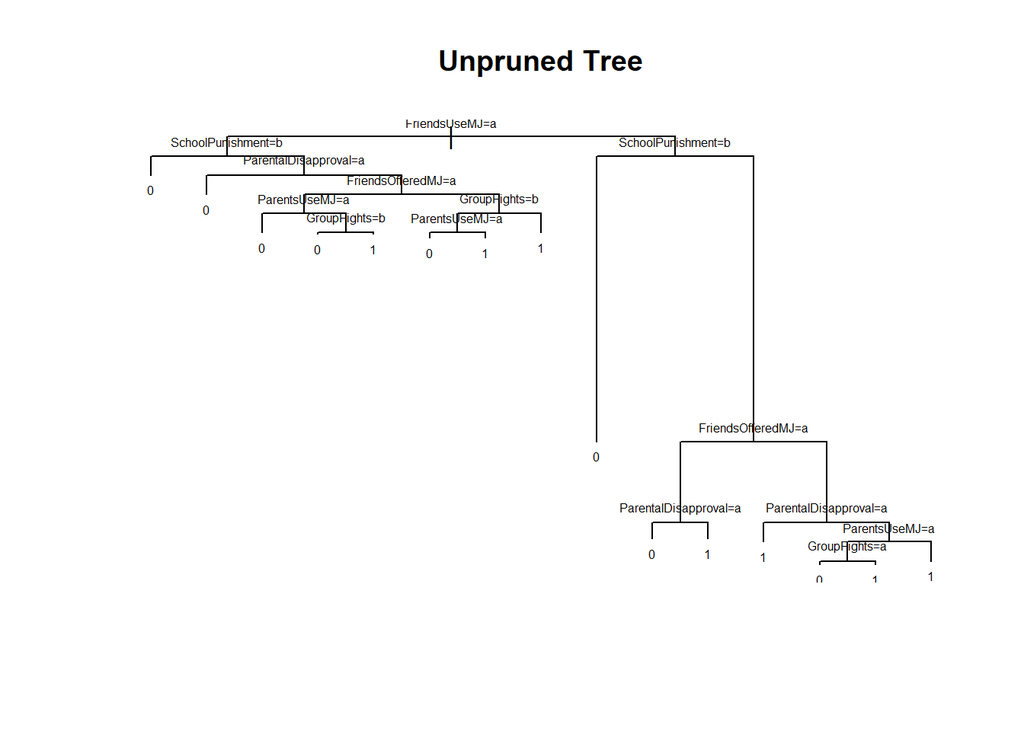

```r
plot(tree_unpruned, main="Unpruned Tree")
text(tree_unpruned, cex=0.5)
```

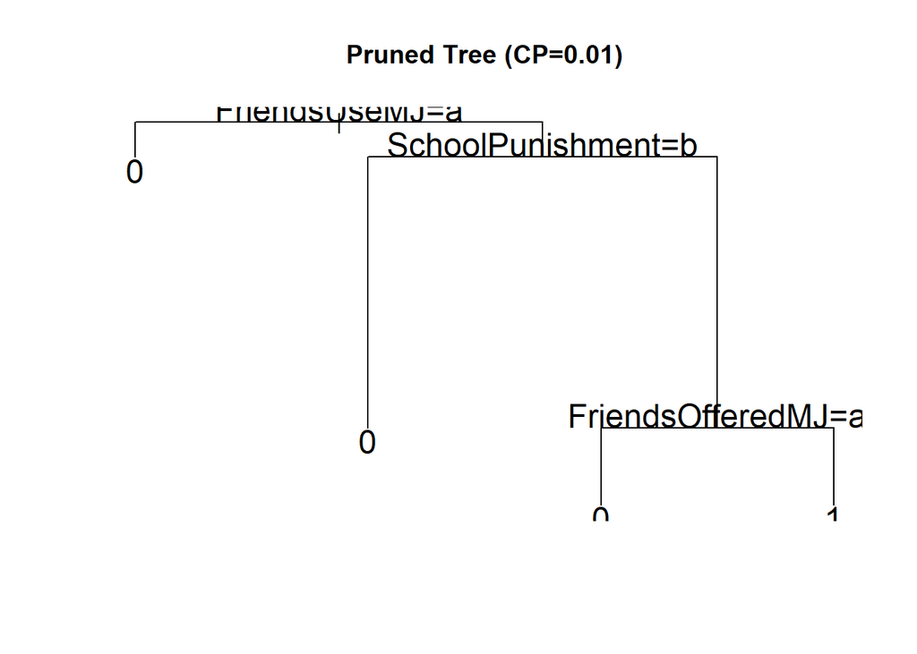

```r
plot(pruned_tree, main="Pruned Tree (CP=0.01)")
text(pruned_tree, cex=1.5)
```

cex helped me to adjust the text size in the plot, so utilizing it for better visualization.

```r
tree_preds <- predict(tree_unpruned, data.test, type = "class")
```

```r
confusionMatrix(tree_preds, as.factor(data.test$MarijuanaUse))
```

```
## Confusion Matrix and Statistics
##
##           Reference
## Prediction    0    1
##          0 2410  245
##          1  114  220
##
##                Accuracy : 0.8799
##                  95% CI : (0.8677, 0.8913)
##     No Information Rate : 0.8444
##     P-Value [Acc > NIR] : 1.883e-08
##
##                   Kappa : 0.4835
##
##  Mcnemar's Test P-Value : 6.831e-12
##
##             Sensitivity : 0.9548
##             Specificity : 0.4731
##          Pos Pred Value : 0.9077
##          Neg Pred Value : 0.6587
##              Prevalence : 0.8444
##          Detection Rate : 0.8063
##    Detection Prevalence : 0.8883
##       Balanced Accuracy : 0.7140
##
##        'Positive' Class : 0
##
```

Pruning simplifies the tree but may sacrifice slight or no accuracy.

# Bagging

```r
bag_binary <- randomForest(
  x = data.train[, predictors_binary],
  y = as.factor(data.train[, target_binary]),
  mtry = 6, # p -> bagging
  ntree = 500,
  importance = TRUE
)
```

[figure not shown]

```r
varImpPlot(bag_binary, col = "blue", main = "Variable Importance (Alcohol Frequency)")
```

```r
bag_preds <- predict(bag_binary, data.test[, predictors_binary])
```

```r
confusionMatrix(bag_preds, as.factor(data.test$MarijuanaUse))
```

```
## Confusion Matrix and Statistics
##
##           Reference
## Prediction    0    1
##          0 2411  246
##          1  113  219
##
##                Accuracy : 0.8799
##                  95% CI : (0.8677, 0.8913)
##     No Information Rate : 0.8444
##     P-Value [Acc > NIR] : 1.883e-08
##
##                   Kappa : 0.4825
##
##  Mcnemar's Test P-Value : 3.245e-12
##
##             Sensitivity : 0.9552
##             Specificity : 0.4710
##          Pos Pred Value : 0.9074
##          Neg Pred Value : 0.6596
##              Prevalence : 0.8444
##          Detection Rate : 0.8066
##    Detection Prevalence : 0.8889
##       Balanced Accuracy : 0.7131
##
##        'Positive' Class : 0
##
```

Bagging (mtry=6) Variable Importance: SchoolPunishment and FriendsUseMJ most influential.

# Random Forest

```r
rf_binary <- randomForest(
  x = data.train[, predictors_binary],
  y = as.factor(data.train[, target_binary]),
  mtry = sqrt(6),  # I am considering square root of p for classification
  ntree = 500,
  importance = TRUE
)
```

```r
print(rf_binary)
```

```
##
## Call:
##  randomForest(x = data.train[, predictors_binary], y = as.factor(data.train[,      target_binary]), ntree = 500, mtry = sqrt(6), importance = TRUE)
##                Type of random forest: classification
##                      Number of trees: 500
## No. of variables tried at each split: 2
##
##         OOB estimate of  error rate: 12.44%
## Confusion matrix:
##      0   1 class.error
## 0 5631 259  0.04397284
## 1  609 476  0.56129032
```

[figure not shown]

```r
varImpPlot(rf_binary, col = "orange", main = "Variable Importance (Alcohol Frequency)")
```

```r
rf_preds <- predict(rf_binary, data.test[, predictors_binary])
```

```r
confusionMatrix(rf_preds, as.factor(data.test$MarijuanaUse))
```

```
## Confusion Matrix and Statistics
##
##           Reference
## Prediction    0    1
##          0 2415  254
##          1  109  211
##
##                Accuracy : 0.8786
##                  95% CI : (0.8663, 0.8901)
##     No Information Rate : 0.8444
##     P-Value [Acc > NIR] : 6.278e-08
##
##                   Kappa : 0.4704
##
##  Mcnemar's Test P-Value : 4.092e-14
##
##             Sensitivity : 0.9568
##             Specificity : 0.4538
##          Pos Pred Value : 0.9048
##          Neg Pred Value : 0.6594
##              Prevalence : 0.8444
##          Detection Rate : 0.8080
##    Detection Prevalence : 0.8929
##       Balanced Accuracy : 0.7053
##
##        'Positive' Class : 0
##
```

Random Forest (mtry=sqrt(6) almost equals 2) Performance: Accuracy: 87.86% slightly lower than bagging. 45.38% (struggled with identifying marijuana users.

Variable Importance: Similar to bagging but with slight difference..

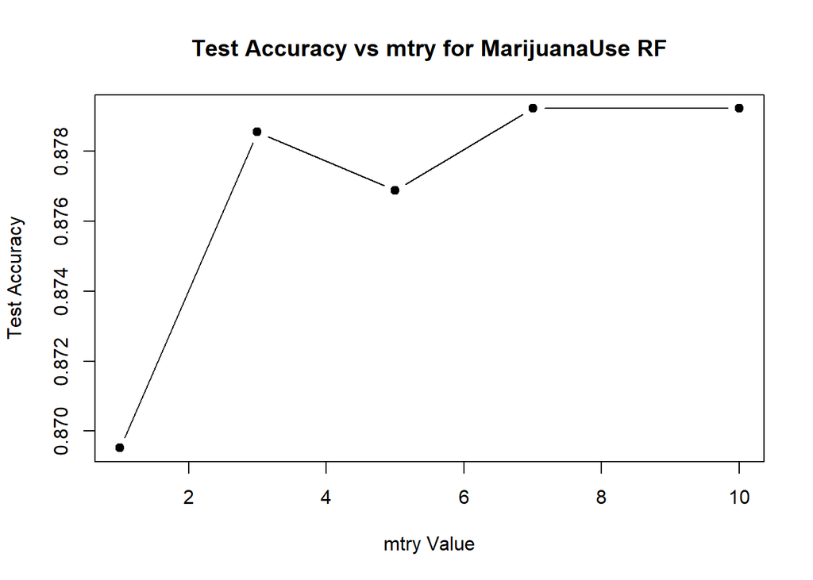

```r
# Implemented Test accuracy for different mtry values as performed in worksheet
test_acc <- c()
for (p in c(1, 3, 5, 7, 10)) {
  rf.temp <- randomForest(
    x = data.train[, predictors_binary],
    y = as.factor(data.train[, target_binary]),
    mtry = sqrt(p),
    ntree = 500
  )
  pred <- predict(rf.temp, newdata = data.test[, predictors_binary])
  acc <- mean(pred == data.test$MarijuanaUse)
  test_acc <- c(test_acc, acc)
}

plot(c(1, 3, 5, 7, 10), test_acc, type = "b", pch = 19,
     xlab = "mtry Value", ylab = "Test Accuracy",
     main = "Test Accuracy vs mtry for MarijuanaUse RF")
```

# Boosting

```r
table(data.train[[target_binary]])
```

```
##
##    0    1
## 5890 1085
```

```r
data.train[[target_binary]] <- as.integer(as.factor(data.train[[target_binary]])) - 1
```

```r
boost_binary <- gbm(
  formula = as.formula(paste(target_binary, "~", paste(predictors_binary, collapse = "+"))),
  data = data.train,
  distribution = "bernoulli",  # binary classification = bernoulli
  n.trees = 1000,
  interaction.depth = 4,
  shrinkage = 0.01,
  verbose = FALSE
)
```

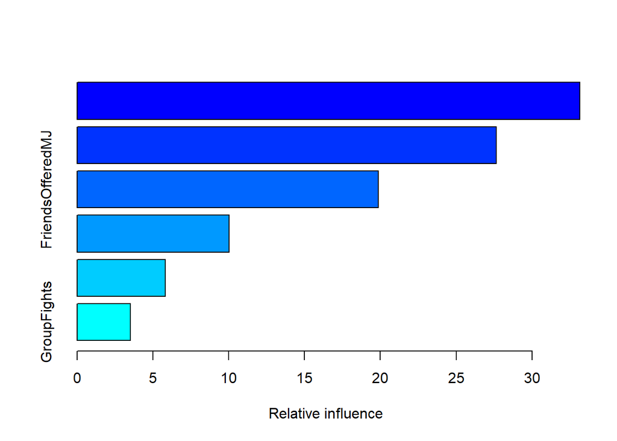

```
##                                     var   rel.inf
## SchoolPunishment       SchoolPunishment 33.154473
## FriendsUseMJ               FriendsUseMJ 27.642950
## FriendsOfferedMJ       FriendsOfferedMJ 19.853881
## ParentalDisapproval ParentalDisapproval 10.021578
## ParentsUseMJ               ParentsUseMJ  5.822251
## GroupFights                 GroupFights  3.504867
```

```r
summary(boost_binary)
```

```r
gbm.perf(boost_binary)
```

```
## OOB generally underestimates the optimal number of iterations although predictive performance is reasonably competitive. Using cv_folds>1 when calling gbm usually results in improved predictive performance.
```

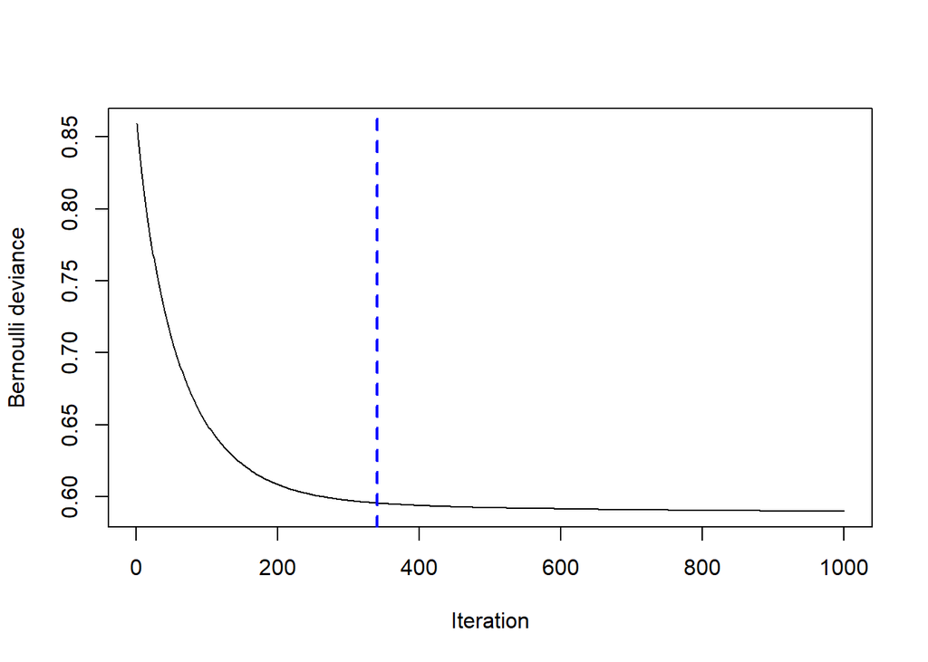

```
## [1] 341
## attr(,"smoother")
## Call:
## loess(formula = object$oobag.improve ~ x, enp.target = min(max(4,
##     length(x)/10), 50))
##
## Number of Observations: 1000
## Equivalent Number of Parameters: 40
## Residual Standard Error: 1.788e-05
```

350 iteration seems best.

```r
### ROC Curve (Boosting)
```

```r
boost_probs <- predict(boost_binary, data.test, n.trees = 1000, type = "response")
boost_preds <- ifelse(boost_probs > 0.5, 1, 0)
```

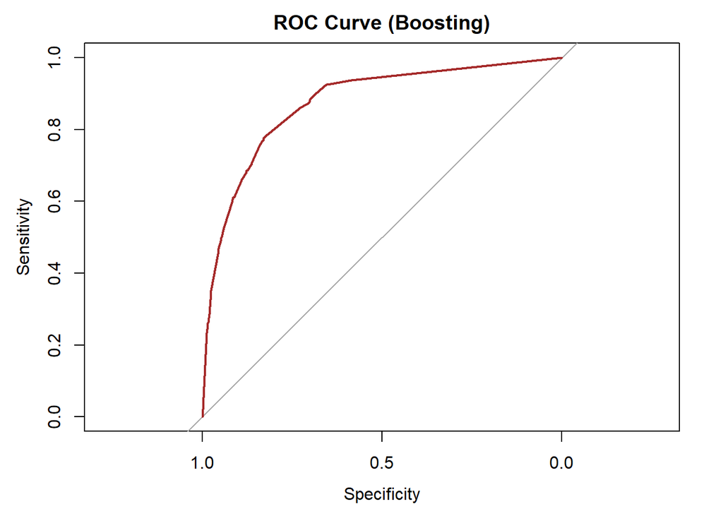

```r
roc_curve <- roc(data.test$MarijuanaUse, boost_probs)
plot(roc_curve, main = "ROC Curve (Boosting)", col = "brown")
```

```r
confusionMatrix(as.factor(boost_preds), as.factor(data.test$MarijuanaUse))
```

```
## Confusion Matrix and Statistics
##
##           Reference
## Prediction    0    1
##          0 2405  244
##          1  119  221
##
##                Accuracy : 0.8786
##                  95% CI : (0.8663, 0.8901)
##     No Information Rate : 0.8444
##     P-Value [Acc > NIR] : 6.278e-08
##
##                   Kappa : 0.4808
##
##  Mcnemar's Test P-Value : 7.600e-11
##
##             Sensitivity : 0.9529
##             Specificity : 0.4753
##          Pos Pred Value : 0.9079
##          Neg Pred Value : 0.6500
##              Prevalence : 0.8444
##          Detection Rate : 0.8046
##    Detection Prevalence : 0.8862
##       Balanced Accuracy : 0.7141
##
##        'Positive' Class : 0
##
```

Accuracy: 87.86% similar to RF but better class separation.

Top Predictor: SchoolPunishment with 33.15% relative influence.

ROC Curve: Strong true positive rate (sensitivity) vs. false positive rate.

Results Summary

Key Insight: Top Predictors: School Punishment, Friends Use MJ, Friends Offered MJ (highest importance in boosting). Parental disapproval and peer influence significantly impact marijuana use.

Model Performance Comparison: Model Accuracy Sensitivity Decision Tree 87.99% 95.48% Bagging 87.99% 95.52% Random Forest 87.86% 95.68% Boosting 87.86% 95.29%

## 2. Multi-Class Classification: Predicting Alcohol Frequency (AlcoholFreq)

# Data Prep

```r
target_multi <- "AlcoholFreq"
df <- df %>% rename(AlcoholFreq = IRALCFY)
```

```r
predictors_multi <- c(
  "Grades",
  "PhysicalFights",
  "Gender",
  "Race",
  "Income",
  "SchoolSafety"
)
```

```r
df <- df %>% rename(
  Gender = IRSEX,
  Race = NEWRACE2,
  Income = INCOME,
  Grades = AVGGRADE,
  SchoolSafety = SCHFELT,
  PhysicalFights = YOFIGHT2
)
```

```r
df$AlcoholFreq <- as.factor(df$AlcoholFreq)
```

Helps lock the factor levels for target variable, ensuring consistent levels across training and testing sets. Implemented several times throughout the code. Refernce: https://stackoverflow.com/questions/39543606/r-getting-column-of-dataframe-from-string/39543627#39543627

```r
predictors_multi <- c("Gender", "Race", "Income", "Grades", "SchoolSafety", "PhysicalFights")
target_multi <- "AlcoholFreq"
```

```r
clean_df <- na.omit(df[, c(target_multi, predictors_multi)])


clean_df[[target_multi]] <- as.factor(clean_df[[target_multi]])
```

```r
set.seed(1)
train <- createDataPartition(clean_df[[target_multi]], p = 0.7, list = FALSE)
data.train <- clean_df[train, ]
data.test <- clean_df[-train, ]
```

# Decision Tree

```r
#By default a Pruned tree as well as considering cp as 0.01
tree_multi <- rpart(
  paste(target_multi, "~", paste(predictors_multi, collapse = "+")),
  data = data.train,
  method = "class",
  control = rpart.control(cp = 0.01)
)
```

[figure not shown]

```r
plot(tree_unpruned, uniform = TRUE, margin = 0.1)
text(tree_unpruned, use.n = TRUE, cex = 0.7)
```

```r
tree_preds <- predict(tree_multi, data.test, type = "class")
```

```r
confusionMatrix(tree_preds, data.test$AlcoholFreq)
```

```
## Confusion Matrix and Statistics
##
##           Reference
## Prediction    1    2    3    4    5    6    7    8    9   10   11   12   13
##        1      0    0    0    0    0    0    0    0    0    0    0    0    0
##        2      0    0    0    0    0    0    0    0    0    0    0    0    0
##        3      0    0    0    0    0    0    0    0    0    0    0    0    0
##        4      0    0    0    0    0    0    0    0    0    0    0    0    0
##        5      0    0    0    0    0    0    0    0    0    0    0    0    0
##        6      0    0    0    0    0    0    0    0    0    0    0    0    0
##        7      0    0    0    0    0    0    0    0    0    0    0    0    0
##        8      0    0    0    0    0    0    0    0    0    0    0    0    0
##        9      0    0    0    0    0    0    0    0    0    0    0    0    0
##        10     0    0    0    0    0    0    0    0    0    0    0    0    0
##        11     0    0    0    0    0    0    0    0    0    0    0    0    0
```

[output cut: 807 more lines]

Decision Tree (Pruned, CP=0.01) Performance:

Accuracy: 77.62% (driven by dominant class “991”). Issue: Severe class imbalance (e.g., class 991 = 77.6%. This seems to because the data is not cleaned properly and sp not balanced. Takeaway: Handle the class class 991 to know actual model performance.

# Bagging

```r
# Written this line as the unused factors were creating an issue so found a way to drop unused factor levels.
data.train[[target_multi]] <- droplevels(data.train[[target_multi]])

bag_multi <- randomForest(
  x = data.train[, predictors_multi],
  y = data.train[[target_multi]],
   mtry = 6,
  ntree = 500,
  importance = TRUE
)
```

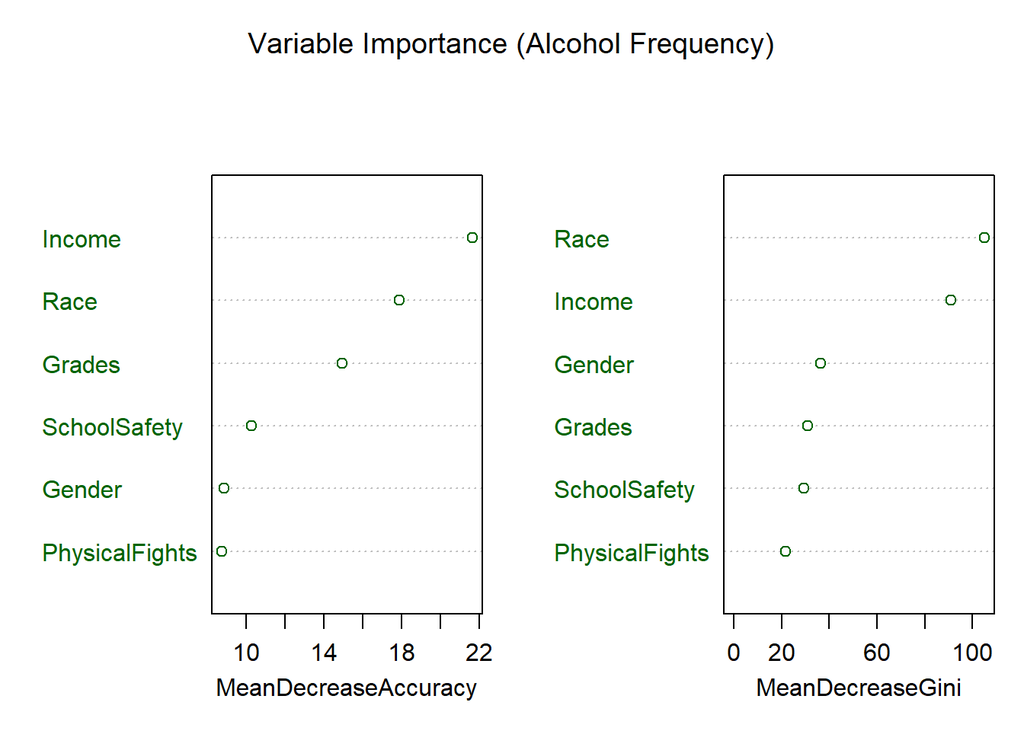

```r
varImpPlot(bag_multi, col = "darkgreen", main = "Variable Importance (Alcohol Frequency)")
```

```r
print(bag_multi)
```

```
##
## Call:
##  randomForest(x = data.train[, predictors_multi], y = data.train[[target_multi]],      ntree = 500, mtry = 6, importance = TRUE)
##                Type of random forest: classification
##                      Number of trees: 500
## No. of variables tried at each split: 6
##
##         OOB estimate of  error rate: 24.35%
## Confusion matrix:
##     1 2 3 4 5 6 7 8 9 10 11 12 13 14 15 16 17 18 19 20 21 22 23 24 25 26 27 28
## 1   0 0 0 0 0 0 0 0 0  0  0  0  0  0  0  0  0  0  0  0  0  0  0  0  0  0  0  0
## 2   0 0 0 0 0 1 0 0 0  0  0  0  0  0  0  0  0  0  0  0  0  0  0  0  0  0  0  0
## 3   0 0 0 0 0 0 1 0 0  0  0  0  0  0  0  0  0  0  0  0  0  0  0  0  0  0  0  0
## 4   0 0 0 0 0 0 0 0 0  0  0  0  0  0  0  0  0  0  0  0  0  0  0  0  0  0  0  0
## 5   0 0 0 0 0 0 0 0 0  0  0  0  0  0  0  1  0  0  0  0  0  0  0  0  0  0  1  0
```

[output cut: 338 more lines]

```r
bag_preds <- predict(bag_multi, data.test)
```

```r
# Again, this line helps maintaining the levels while&after predictions
bag_preds <- factor(bag_preds, levels = levels(data.test$AlcoholFreq))
```

```r
confusionMatrix(bag_preds, data.test$AlcoholFreq)
```

```
## Confusion Matrix and Statistics
##
##           Reference
## Prediction    1    2    3    4    5    6    7    8    9   10   11   12   13
##        1      0    0    0    0    0    0    0    0    0    0    0    0    0
##        2      0    0    0    0    0    0    0    0    0    0    0    1    0
##        3      0    1    0    0    0    0    0    0    0    0    0    0    0
##        4      0    0    0    0    0    0    0    0    0    0    0    0    0
##        5      0    0    0    0    0    0    0    0    0    0    0    0    0
##        6      0    0    0    0    0    0    0    0    0    0    0    0    0
##        7      0    0    0    0    0    0    0    0    0    0    0    0    0
##        8      0    0    0    0    0    0    0    0    0    0    0    0    0
##        9      0    0    0    0    0    0    0    0    0    0    0    0    0
##        10     0    0    0    0    0    0    0    0    0    0    0    0    0
##        11     0    0    0    0    0    0    0    0    0    0    0    0    0
```

[output cut: 807 more lines]

Bagging (mtry=6) Performance: Accuracy: 77.03% (no improvement over tree). OOB Error: 24.35%. Variable Importance: Income, Race, and Grades most influential.

# Random Forest

```r
rf_multi <- randomForest(
  x = data.train[, predictors_multi],
  y = data.train$AlcoholFreq,
  mtry = sqrt(6),
  ntree = 500,
  importance = TRUE
)
```

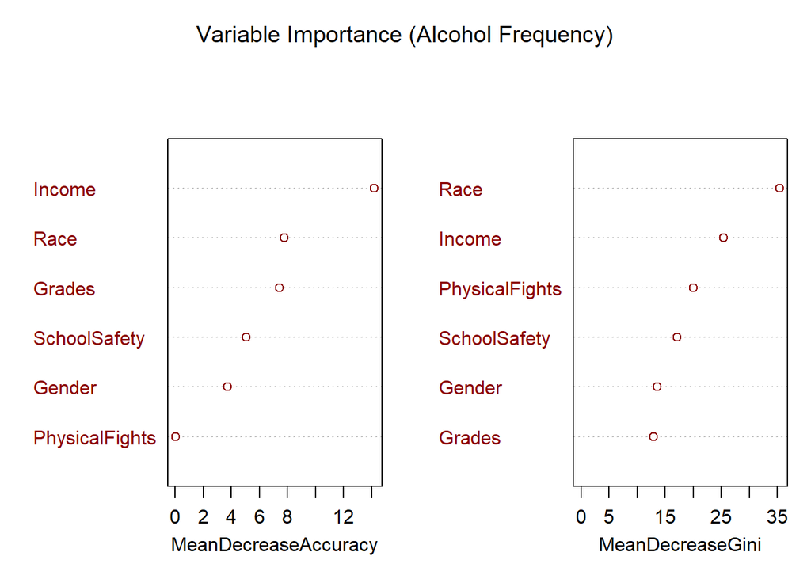

```r
varImpPlot(rf_multi, col = "darkred", main = "Variable Importance (Alcohol Frequency)")
```

```r
rf_preds <- predict(rf_multi, data.test)
```

```r
rf_preds <- factor(rf_preds, levels = levels(data.test$AlcoholFreq))
```

```r
confusionMatrix(rf_preds, data.test$AlcoholFreq)
```

```
## Confusion Matrix and Statistics
##
##           Reference
## Prediction    1    2    3    4    5    6    7    8    9   10   11   12   13
##        1      0    0    0    0    0    0    0    0    0    0    0    0    0
##        2      0    0    0    0    0    0    0    0    0    0    0    0    0
##        3      0    0    0    0    0    0    0    0    0    0    0    0    0
##        4      0    0    0    0    0    0    0    0    0    0    0    0    0
##        5      0    0    0    0    0    0    0    0    0    0    0    0    0
##        6      0    0    0    0    0    0    0    0    0    0    0    0    0
##        7      0    0    0    0    0    0    0    0    0    0    0    0    0
##        8      0    0    0    0    0    0    0    0    0    0    0    0    0
##        9      0    0    0    0    0    0    0    0    0    0    0    0    0
##        10     0    0    0    0    0    0    0    0    0    0    0    0    0
##        11     0    0    0    0    0    0    0    0    0    0    0    0    0
```

[output cut: 807 more lines]

Random Forest (mtry= sqrt(6) = almost 2) Performance: Accuracy: 77.62% (same as decision tree). No meaningful improvement due to extreme imbalance.

Result Summary: Top Predictors: Income, Race, Grades (most influential in RF/bagging). School safety and gender had moderate effects.

Model Performance Comparison: Model Accuracy Decision Tree 77.62% Bagging 77.03% Random Forest 77.62%

Key Issues: High class imbalance (class 991). Class Imbalance issue. Takeaway: class 991 should be handled to improve model performance.

Recommendation: Address imbalance (e.g., oversampling) or consolidate categories.

Key Insight: Income, Race, Grades are most influential in RF and bagging.

# 3. Regression: Predicting Cigarette Usage Days (CigaretteUsageDays)

# Prep

```r
rm(list = ls())
load("youth_data.Rdata")
ls()
```

```
## [1] "demographic_cols"      "df"                    "substance_cols"
## [4] "youth_experience_cols"
```

```r
head(df, 5)
```

```
##   IRALCFY IRMJFY IRCIGFM IRSMKLSS30N IRALCFM IRMJFM IRCIGAGE IRSMKLSSTRY
## 1     991    991      91          91      91     91      991         991
## 2     991     60      91          91      91      2      991         991
## 3       1    991      91          91      93     91      991         991
## 4     991    991      91          91      91     91      991         991
## 5     991    991      91          91      91     91      991         991
##   IRALCAGE IRMJAGE MRJFLAG ALCFLAG TOBFLAG ALCYDAYS MRJYDAYS ALCMDAYS MRJMDAYS
## 1      991     991       0       0       0        6        6        5        5
## 2      991      14       1       0       0        6        3        5        1
## 3       11     991       0       1       0        1        6        5        5
## 4      991     991       0       0       0        6        6        5        5
## 5      991     991       0       0       0        6        6        5        5
##   CIGMDAYS SMKLSMDAYS SCHFELT TCHGJOB AVGGRADE STNDSCIG STNDSMJ STNDALC STNDDNK
## 1        6          5       1       1        2        2       2       2       2
## 2        6          5       2       1        2        1       1       1       1
```

[output cut: 45 more lines]

```r
colnames(df)
```

```
##  [1] "IRALCFY"     "IRMJFY"      "IRCIGFM"     "IRSMKLSS30N" "IRALCFM"
##  [6] "IRMJFM"      "IRCIGAGE"    "IRSMKLSSTRY" "IRALCAGE"    "IRMJAGE"
## [11] "MRJFLAG"     "ALCFLAG"     "TOBFLAG"     "ALCYDAYS"    "MRJYDAYS"
## [16] "ALCMDAYS"    "MRJMDAYS"    "CIGMDAYS"    "SMKLSMDAYS"  "SCHFELT"
## [21] "TCHGJOB"     "AVGGRADE"    "STNDSCIG"    "STNDSMJ"     "STNDALC"
## [26] "STNDDNK"     "PARCHKHW"    "PARHLPHW"    "PRCHORE2"    "PRLMTTV2"
## [31] "PARLMTSN"    "PRGDJOB2"    "PRPROUD2"    "ARGUPAR"     "YOFIGHT2"
## [36] "YOGRPFT2"    "YOHGUN2"     "YOSELL2"     "YOSTOLE2"    "YOATTAK2"
## [41] "PRPKCIG2"    "PRMJEVR2"    "PRMJMO"      "PRALDLY2"    "YFLPKCG2"
## [46] "YFLTMRJ2"    "YFLMJMO"     "YFLADLY2"    "FRDPCIG2"    "FRDMEVR2"
## [51] "FRDMJMON"    "FRDADLY2"    "TALKPROB"    "PRTALK3"     "PRBSOLV2"
## [56] "PREVIOL2"    "PRVDRGO2"    "GRPCNSL2"    "PREGPGM2"    "YTHACT2"
## [61] "DRPRVME3"    "ANYEDUC3"    "RLGATTD"     "RLGIMPT"     "RLGDCSN"
## [66] "RLGFRND"     "IRSEX"       "NEWRACE2"    "HEALTH2"     "EDUSCHLGO"
## [71] "EDUSCHGRD2"  "EDUSKPCOM"   "IMOTHER"     "IFATHER"     "INCOME"
## [76] "GOVTPROG"    "POVERTY3"    "PDEN10"      "COUTYP4"
```

```r
target <- "CigaretteUsageDays"
df <- df %>% rename(CigaretteUsageDays = IRCIGFM)
```

```r
predictors <- c(
  "ParentsSmoke",
  "PhysicalFights",
  "StolenItems",
  "FriendsSmoke",
  "PovertyLevel"
)
```

```r
df <- df %>% rename(
  FriendsSmoke = FRDPCIG2,
  ParentsSmoke = PRPKCIG2,
  StolenItems = YOSTOLE2,
  PovertyLevel = POVERTY3,
  PhysicalFights = YOFIGHT2
)
```

```r
df$CigaretteUsageDays <- as.numeric(df$CigaretteUsageDays)
```

```r
predictors <- c("FriendsSmoke", "ParentsSmoke", "PhysicalFights", "StolenItems", "PovertyLevel")
target <- "CigaretteUsageDays"
```

```r
clean_df <- na.omit(df[, c(target, predictors)])

# Here, I have converted the target variable to numeric as I was earlier facing issue without it for further regression modeling.
clean_df[[target]] <- as.numeric(clean_df[[target]])
```

```r
set.seed(1)
train <- createDataPartition(clean_df[[target]], p = 0.7, list = FALSE)
data.train <- clean_df[train, ]
data.test <- clean_df[-train, ]
```

# Decision Tree

```r
tree_model <- rpart(
  paste(target, "~", paste(predictors, collapse = "+")),
  data = data.train,
  method = "anova",
  control = rpart.control(cp = 0.01)
)
# Anova used as method for regression
```

```r
tree_preds <- predict(tree_model, data.test)
tree_mse <- mean((tree_preds - data.test$CigaretteUsageDays)^2)
```

```r
print(paste("Decision Tree Test MSE:", tree_mse))
```

```
## [1] "Decision Tree Test MSE: 125.323222455857"
```

Comments: Decision Tree (Anova with cp=0.01) Performance: MSE: 125.32, RMSE: 11.19. Simple splits based on ParentsSmoke and FriendsSmoke.

# Bagging

```r
bag_model <- randomForest(
  x = data.train[, predictors],
  y = data.train[, target],
  mtry = 5,
  ntree = 500,
  importance = TRUE
)
```

```r
bag_preds <- predict(bag_model, data.test[, predictors])
```

```r
bag_mse <- mean(((bag_preds) - (data.test$CigaretteUsageDays))^2)
print(paste("Bagging Test MSE:", bag_mse))
```

```
## [1] "Bagging Test MSE: 125.937631365414"
```

```r
print(importance(bag_model))
```

```
##                   %IncMSE IncNodePurity
## FriendsSmoke   -4.7412041     10104.207
## ParentsSmoke    0.4946732     10346.373
## PhysicalFights -9.5041583      9303.183
## StolenItems    -6.6673413     10162.075
## PovertyLevel    7.0663007     16413.742
```

Comments: Bagging (mtry=5) Performance: MSE: 125.94 (slightly worse than decision tree).

Variable Importance:

PovertyLevel had the highest node purity.

# Random Forest

```r
rf_model <- randomForest(
  x = data.train[, predictors],
  y = data.train[, target],
  mtry = 5/3,  # p/3 for regression and RF
  ntree = 500,
  importance = TRUE
)
```

```r
rf_preds <- predict(rf_model, data.test[, predictors])
rf_mse <- mean((rf_preds - data.test$CigaretteUsageDays)^2)
```

```r
print(paste("Random Forest Test MSE:", rf_mse))
```

```
## [1] "Random Forest Test MSE: 123.840135100279"
```

```r
print(importance(rf_model))
```

```
##                  %IncMSE IncNodePurity
## FriendsSmoke   -2.134320      3962.496
## ParentsSmoke    9.432614      9131.520
## PhysicalFights -4.663662      4111.998
## StolenItems     5.568634      8812.460
## PovertyLevel    5.773618      7127.117
```

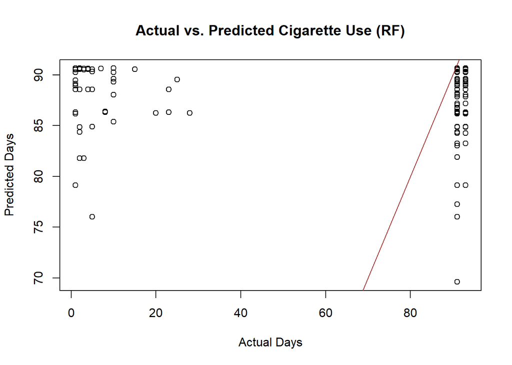

```r
plot(data.test$CigaretteUsageDays, rf_preds,
     xlab = "Actual Days", ylab = "Predicted Days",
     main = "Actual vs. Predicted Cigarette Use (RF)")
abline(0, 1, col = "brown")
```

Comments:

Random Forest (mtry=5/3, almost 1) Best Model as MSE: 123.84 (is lowest). Variable Importance: Parents Smoke and Stolen Items most impactful. For plot, points close to brown line = Accurate predictions.

# Boosting

```r
boost_model <- gbm(
  formula = as.formula(paste(target, "~", paste(predictors, collapse = "+"))),
  data = data.train,
  distribution = "gaussian",
  n.trees = 1000,
  interaction.depth = 4,
  shrinkage = 0.01,
  verbose = FALSE
)
```

```r
boost_preds <- predict(boost_model, data.test, n.trees = 1000)
boost_mse <- mean((boost_preds - data.test$CigaretteUsageDays)^2)
```

```r
print(paste("Boosting Test MSE:", boost_mse))
```

```
## [1] "Boosting Test MSE: 125.196172397436"
```

Trying on different shrinkage value and respective plot - trying similar to implementated in worksheet and practice In Class Work.

```r
lambdas <- c(0.001, 0.01, 0.05, 0.1, 0.2, 0.5, 1)
train_mse <- c()
test_mse <- c()
```

Helps to loop through and get test, train MSE value to plot and find the best lambda value.

```r
for (lambda in lambdas) {
  set.seed(1)
  boost_model <- gbm(
    formula = as.formula(paste(target, "~", paste(predictors, collapse = "+"))),
    data = data.train,
    distribution = "gaussian",
    n.trees = 1000,
    shrinkage = lambda,
    interaction.depth = 4,
    verbose = FALSE
  )

  pred_train <- predict(boost_model, data.train, n.trees = 1000)
  train_mse <- c(train_mse, mean((pred_train - data.train[[target]])^2))

  pred_test <- predict(boost_model, data.test, n.trees = 1000)
  test_mse <- c(test_mse, mean((pred_test - data.test[[target]])^2))
}
```

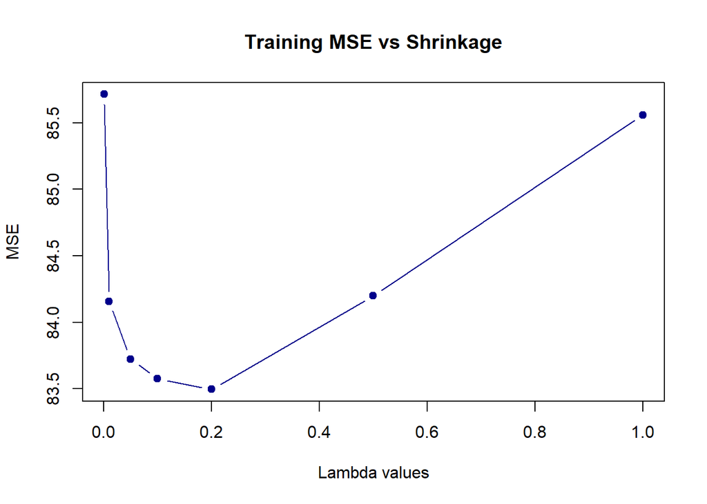

```r
plot(lambdas, train_mse, type = "b", pch = 19, col = "darkblue",
     xlab = "Lambda values", ylab = "MSE",
     main = "Training MSE vs Shrinkage")
```

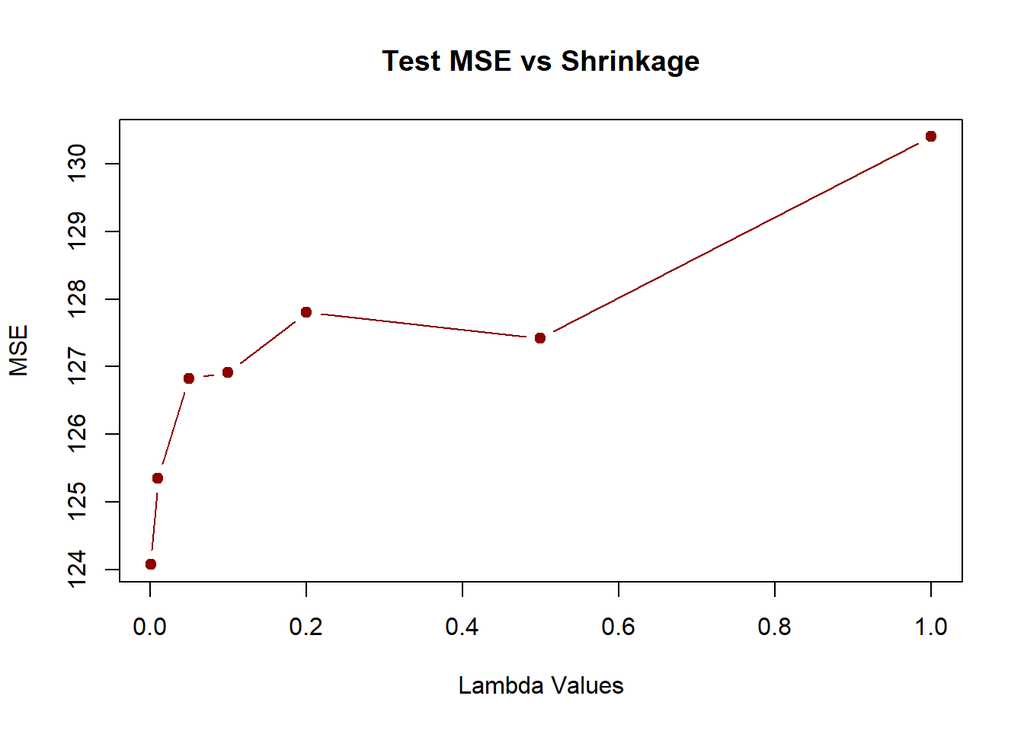

```r
plot(lambdas, test_mse, type = "b", pch = 19, col = "darkred",
     xlab = "Lambda Values", ylab = "MSE",
     main = "Test MSE vs Shrinkage")
```

```r
best_lambda <- lambdas[which.min(test_mse)]
cat("Optimal shrinkage parameter:", best_lambda, "\n")
```

```
## Optimal shrinkage parameter: 0.001
```

```r
boost_model <- gbm(
  formula = as.formula(paste(target, "~", paste(predictors, collapse = "+"))),
  data = data.train,
  distribution = "gaussian",
  n.trees = 1000,
  shrinkage = best_lambda,
  interaction.depth = 4,
  verbose = FALSE
)
```

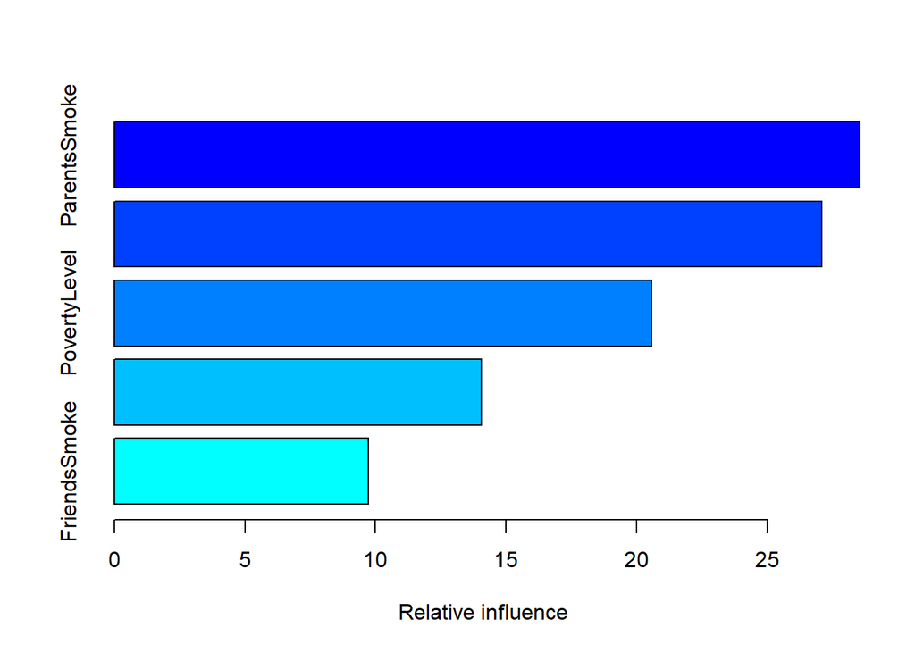

```
##                           var   rel.inf
## ParentsSmoke     ParentsSmoke 28.554169
## StolenItems       StolenItems 27.090367
## PovertyLevel     PovertyLevel 20.565078
## PhysicalFights PhysicalFights 14.052859
## FriendsSmoke     FriendsSmoke  9.737526
```

```r
# It will help me get the variable importance
print(summary(boost_model))
```

```r
library(pdp)
```

```r
partial_data <- partial(
  boost_model,
  pred.var = "ParentsSmoke",  # Top predictor -> replaced manually
  train = data.train,
  n.trees = 1000,
  type = "regression"
)
```

n.trees should be same as in training model.

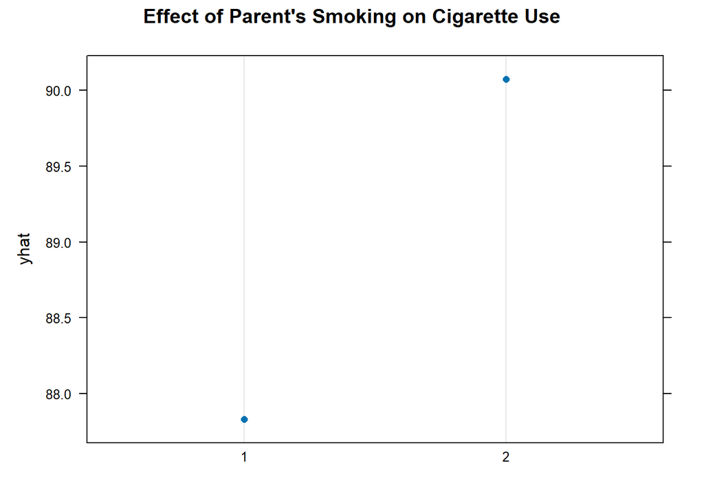

```r
plotPartial(partial_data, main = "Effect of Parent's Smoking on Cigarette Use")
```

[figure not shown]

```r
plot(partial_data,
     type = "l",
     main = "Partial Dependence: Friends' Smoking Effect",
     xlab = "Number of Friends Who Smoke (FRDPCIG2)",
     ylab = "Predicted Cigarette Use Days",
     col = "gold",
     lwd = 2)
grid()
```

Comments:

Boosting (GBM) Optimal Lambda: 0.001.

Performance: MSE: 125.20 (close to decision tree).

Top Predictor: Parents Smoke has 28.55% relative influence.

Partial Dependence Plot: Linear increase in predicted use with higher Parents Smoke.

# Results Comparison

```r
results <- data.frame(
  Model = c("Decision Tree", "Bagging", "Random Forest", "Boosting"),
  MSE = c(tree_mse, bag_mse, rf_mse, boost_mse)
)

print(results)
```

```
##           Model      MSE
## 1 Decision Tree 125.3232
## 2       Bagging 125.9376
## 3 Random Forest 123.8401
## 4      Boosting 125.1962
```

```r
RMSE = sqrt(c(tree_mse, bag_mse, rf_mse, boost_mse))

results <- data.frame(
  Model = c("Decision Tree", "Bagging", "Random Forest", "Boosting"),
  RMSE = RMSE
)
results
```

```
##           Model     RMSE
## 1 Decision Tree 11.19479
## 2       Bagging 11.22219
## 3 Random Forest 11.12835
## 4      Boosting 11.18911
```

```r
# Variable importance comparison
varImpCompare <- cbind(
  Bagging = importance(bag_model)[,1],
  RF = importance(rf_model)[,1],
  Boost = summary(boost_model)$rel.inf
)
```

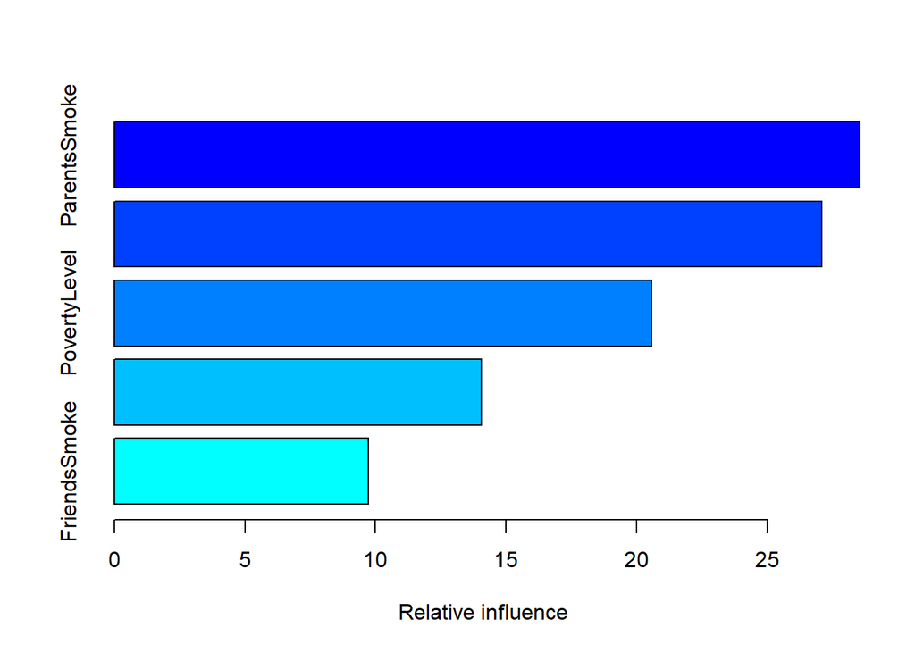

Key Findings: Top Predictors: Parents Smoke (28.6% rel. influence in boosting), with Stolen Items, Poverty Level.

Model Performance Comparison:

Model MSE RMSE Decision Tree 125.32 11.19  
Bagging 125.94 11.22  
Random Forest 123.84 11.13  
Boosting 125.20 11.19

Key Insight:

Random Forest had the lowest MSE (123.84), making it the best regression model.

Boosting’s partial dependence plots revealed parental smoking increased predicted use.